**gatepoints** provides an easy to use function, **fhs** (freehand select) for gating or selecting points freehand on a plot. If using from RStudio please use X11 display for a better user experience. Take the simple plot below:

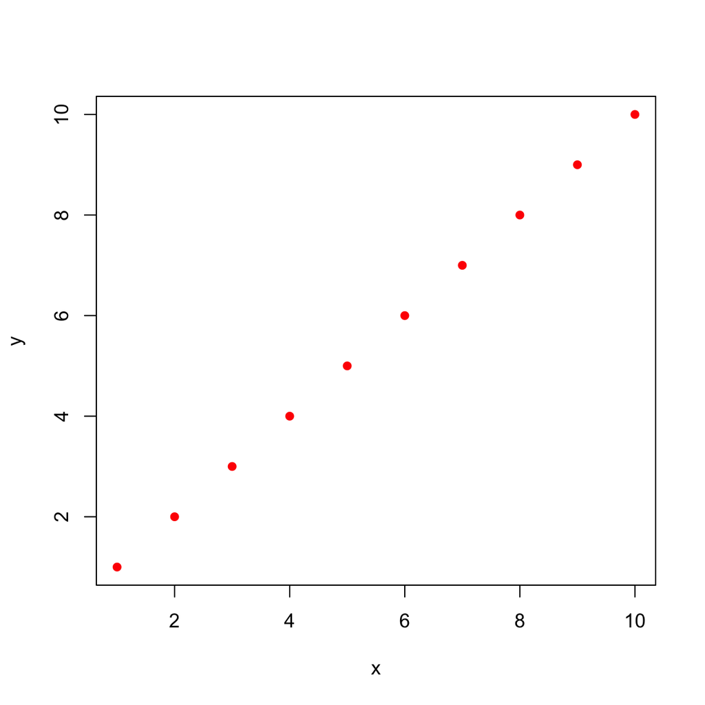

Simple plot.

```r
x <- data.frame(x=1:10, y=1:10, row.names = 1:10)
## If you are using RStudio do X11() first.
plot(x, pch = 16, col = "red")
```

```r
library(gatepoints)
selectedPoints <- fhs(x, mark = TRUE)
```

To select an arbitrarily complex region run the above commands and proceed as follows:

1. Mark region of your choice by **left clicking** around your region of interest.
2. Close polygon by **right clicking**. On the Windows platform click **stop** after right clicking.

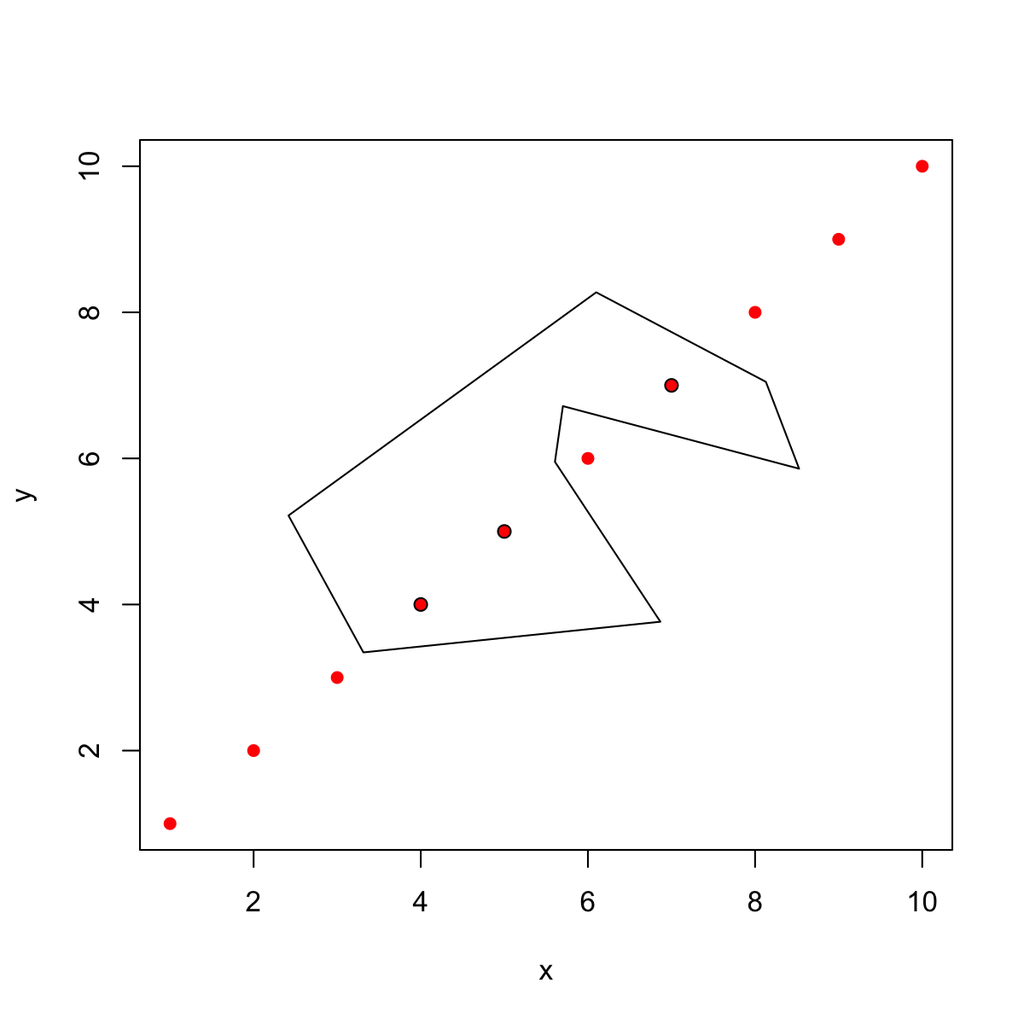

Selected points

The points can be marked as defined by the user with additional parameters passed to the **points** function. The names of the points as given by the rownames of the data frame **x** will be returned in **selectedPoints**. Additionally the points selected for the gate will be returned as the **gate** attribute.

```r
selectedPoints
```

```
## [1] "4" "5" "7"
## attr(,"gate")
##          x        y
## 1 6.099191 8.274120
## 2 8.129107 7.048649
## 3 8.526881 5.859404
## 4 5.700760 6.716428
## 5 5.605314 5.953430
## 6 6.866882 3.764390
## 7 3.313575 3.344069
## 8 2.417270 5.217868
```